# STATproject

g11470101

2022/11/7

# 研究動機及目的

此資料分析的目的為透過這筆資料找出與中風有關的變數，以及建造模型預測是否中風。

# 資料集定義

此資料來自Kaggle，資料來源內容為保密，僅作為教育目的。

(資料來源: https://www.kaggle.com/datasets/fedesoriano/stroke-prediction-dataset?resource=download)

- ID: 患者編號
- gender: 性別(男生、女生或其他)
- age: 病患的年紀
- hypertension: 是否有高血壓(0 = 沒有高血壓, 1 = 有高血壓)
- heart_disease: 是否有心臟病(0 = 沒有心臟病, 1 = 有心臟病)
- ever_married: 是否結婚過(無、有)
- work_type: 工作類別(小孩、政府工作、私有工作、自營、從未工作)
- Residence_type: 區住類別(鄉村、都市)
- avg_glucose_level: 平均血糖濃度
- bmi: 身體質量指數(體重/身高(公尺)平方)
- smoking_status: 抽菸狀態(之前抽過、沒抽過、現在抽、未知)
- stroke: 中風狀態(0 = 沒中風，1 = 有中風)

# 此資料為分類問題

由資料集本身找出重要變數，並建造相關模型，用以預測中風狀態。

# 可能採用的模型或方法

- loglogsitic regression
- bagging
- randomforest

# 載入需要套件

```r
if(!require(dplyr)){install.packages("dplyr")}
if(!require(mice)){install.packages("mice")}
if(!require(ggplot2)){install.packages("ggplot2")}
if(!require(DataExplorer)){install.packages("DataExplorer")}
if(!require(VIM)){install.packages("VIM")}
if(!require(randomForest)){install.packages("randomForest")}
```

# 匯入資料並檢視資料變數型態及樣貌

此資料共有5110筆觀察值，11個變數(扣除ID)。

將一些變數的資料型態做適當的轉換，例如:因為在資料中的bmi是類別型資料，所以必須把bmi轉成連續型資料。

| 資料變數 | 中文說明 | 處理方法 |
| --- | --- | --- |
| gender | 性別 | 轉成類別資料(本來是字串) |
| hypertension | 是否有高血壓 | 轉成01資料(0代表無，1代表有) |
| heart_disease | 是否有心臟病 | 轉成01資料(0代表無，1代表有) |
| ever_married | 是否結過婚 | 轉成01資料(0代表無，1代表有) |
| work_type | 工作類別 | 轉成類別資料(本來是字串) |
| Residence_type | 居住型態 | 轉成01資料(0代表鄉村，1代表都市) |
| bmi | 身體質量指標 | 轉成連續資料(本來是字串) |
| smoking_status | 是否抽過菸 | 轉成類別資料(本來是字串) |
| stroke | 中風狀態 | 轉成01資料(0代表無，1代表有) |

```r
alldata$gender = as.factor(alldata$gender)
alldata$hypertension = as.factor(alldata$hypertension)
alldata$heart_disease = as.factor(alldata$heart_disease)
alldata$ever_married = as.factor(ifelse(alldata$ever_married=="No", 0 ,1))
alldata$work_type = factor(alldata$work_type)
alldata$Residence_type = as.factor(ifelse(alldata$Residence_type =="Rural", 0, 1))
alldata$bmi = as.numeric(alldata$bmi)
alldata$smoking_status = factor(alldata$smoking_status)
alldata$smoking_status = ifelse(alldata$smoking_status=="Unknown", NA, alldata$smoking_status)
alldata$gender = as.factor(ifelse(alldata$gender=="Other", NA, alldata$gender))
alldata$stroke = as.factor(alldata$stroke)
```

# 資料預處理

檢視每個觀察值是否有多個變數缺失的狀況，用`DataExplorer::plot_missing(alldata)`函數看缺失值狀況，單一變數的NA值若超過30%以上，則此變數刪除。

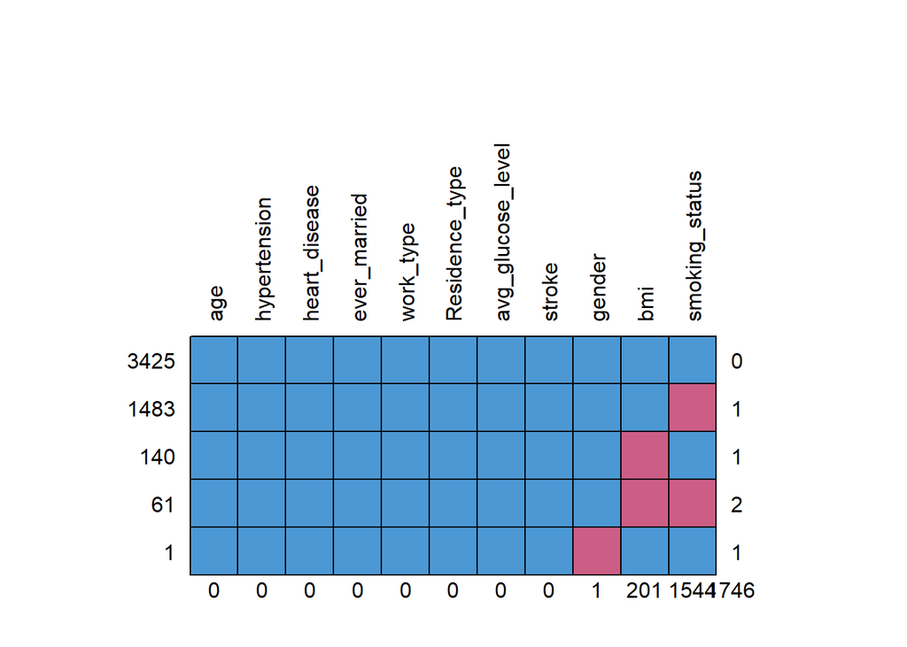

```
##      age hypertension heart_disease ever_married work_type Residence_type
## 3425   1            1             1            1         1              1
## 1483   1            1             1            1         1              1
## 140    1            1             1            1         1              1
## 61     1            1             1            1         1              1
## 1      1            1             1            1         1              1
##        0            0             0            0         0              0
##      avg_glucose_level stroke gender bmi smoking_status
## 3425                 1      1      1   1              1    0
## 1483                 1      1      1   1              0    1
## 140                  1      1      1   0              1    1
## 61                   1      1      1   0              0    2
## 1                    1      1      0   1              1    1
##                      0      0      1 201           1544 1746
```

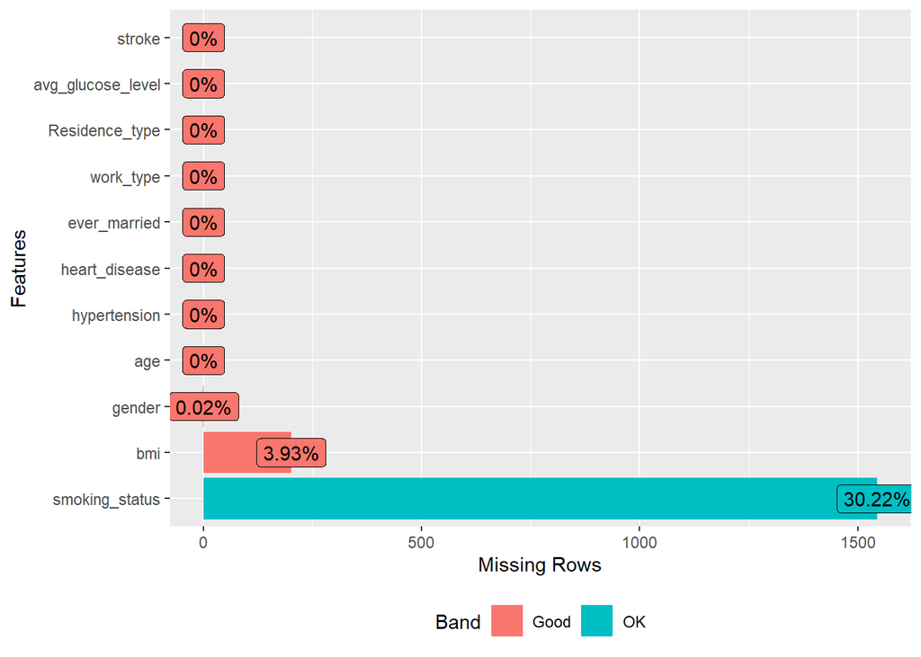

# NA處理

有NA值的變數依照下表做處裡。

[output not shown]

# 單變量圖型

以下都是討論前面步驟做完後的資料:

由於圖表眾多，因此只將有做分析的變數圖表列出，其他則放在附錄A 中風: 大部分都沒有中風。

在bmi和avg_glucose_level兩個變數中，根據箱型圖顯示兩者皆有些離群值，因此接下來刪除離群值。

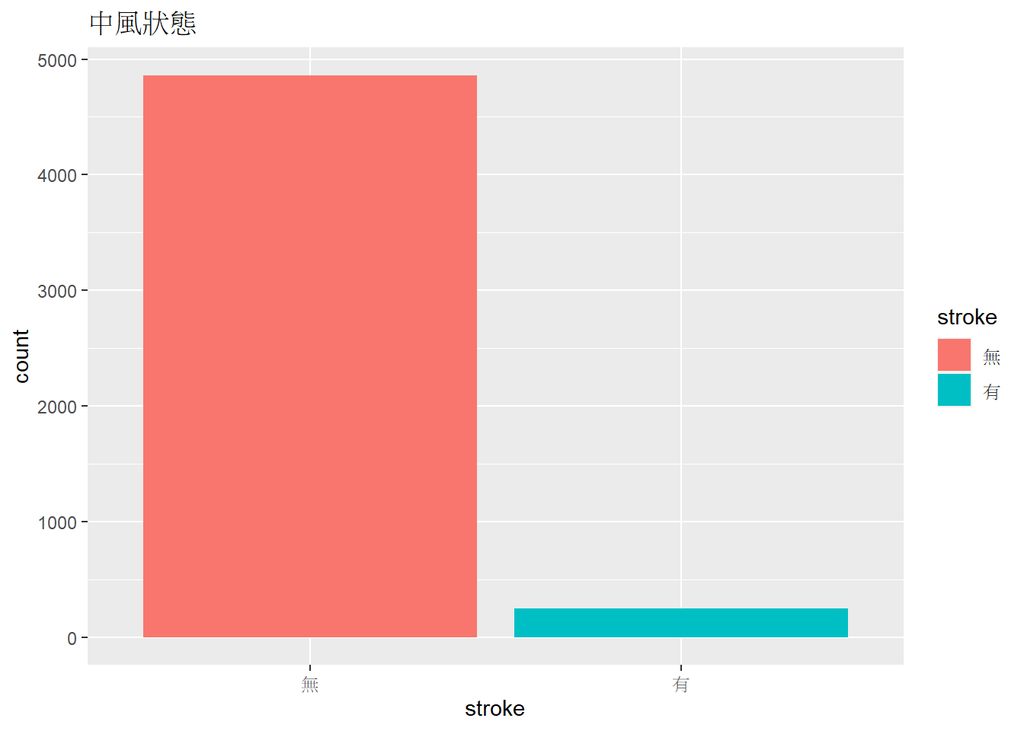

```r
ggplot(alldata, aes(x = stroke, fill = stroke)) +
   geom_bar() +
  ggtitle("中風狀態") + scale_fill_discrete( labels = c("無", "有")) + scale_x_discrete(labels = c("無", "有"))
```

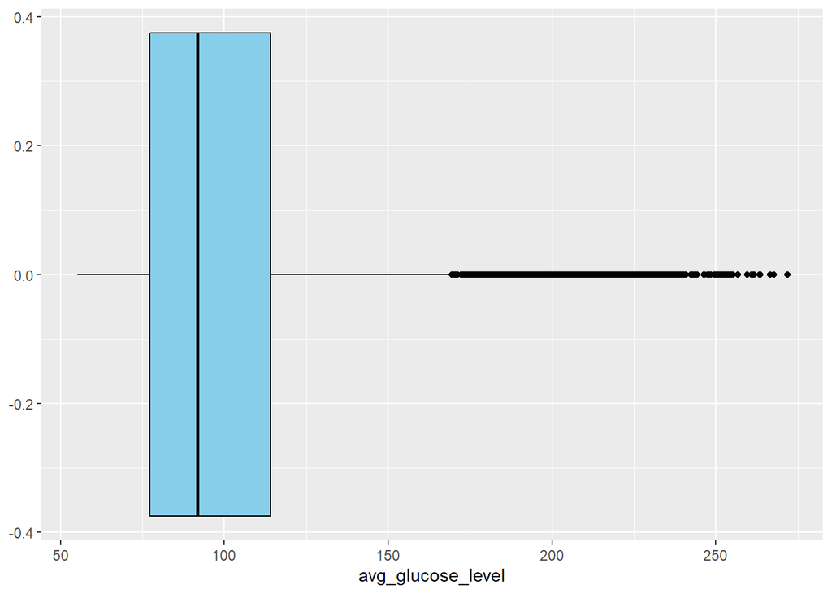

```r
ggplot(alldata, aes(x = avg_glucose_level))+
   geom_boxplot(color="black", fill="skyblue" )
```

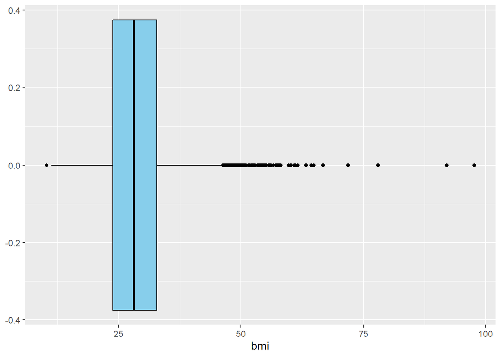

```r
ggplot(alldata, aes(x = bmi))+
   geom_boxplot(color="black", fill="skyblue")
```

# 刪除離群值

由於變數bmi的箱型圖顯示離群值差異相當大，因此將超過箱型圖上界或下界的觀察值移除。

此階段總共刪除了126個值。

最後整理完的資料維度為:4984筆觀察值，10個變數。

## 資料分析及流程

為了在預測結果上有個依據，所以將alldata分為80%的training dataset & 20%的testing dataset。

# 羅吉斯模型

從表可以看到在變數age是顯著的，代表此變數的迴歸係數不為0；而hypertension、heart_disease兩者的變數的基準各別都是跟沒有高血壓，以及沒有心臟病，從結果看出有高血壓的人比沒高血壓的人更容易中風；有心臟病的人比沒心臟病的人更容易中風，雖然此變數的參數估計值並不顯著，但其估計值大於0。

```r
logit = glm(stroke~., family ="binomial", data = train)
summary(logit)
```

```
##
## Call:
## glm(formula = stroke ~ ., family = "binomial", data = train)
##
## Deviance Residuals:
##     Min       1Q   Median       3Q      Max
## -1.1309  -0.3151  -0.1644  -0.0931   3.4537
##
## Coefficients:
##                     Estimate Std. Error z value Pr(>|z|)
## (Intercept)        -6.608750   0.785482  -8.414  < 2e-16 ***
## gender2            -0.010194   0.162984  -0.063  0.95013
## age                 0.072219   0.006517  11.081  < 2e-16 ***
## hypertension1       0.521554   0.186396   2.798  0.00514 **
## heart_disease1      0.406446   0.218926   1.857  0.06338 .
## ever_married1      -0.274232   0.247523  -1.108  0.26790
## work_type2         -0.887197   0.849706  -1.044  0.29643
## work_type3        -10.625362 342.111761  -0.031  0.97522
## work_type4         -0.975207   0.832250  -1.172  0.24129
## work_type5         -1.212380   0.859234  -1.411  0.15824
## Residence_type1     0.170224   0.159394   1.068  0.28555
## avg_glucose_level   0.002051   0.001410   1.454  0.14590
## bmi                 0.008451   0.014479   0.584  0.55943
## ---
## Signif. codes:  0 '***' 0.001 '**' 0.01 '*' 0.05 '.' 0.1 ' ' 1
##
## (Dispersion parameter for binomial family taken to be 1)
##
##     Null deviance: 1504.4  on 3997  degrees of freedom
## Residual deviance: 1211.2  on 3985  degrees of freedom
## AIC: 1237.2
##
## Number of Fisher Scoring iterations: 14
```

```r
my_logit2 <-glm(stroke~ age + hypertension + heart_disease + avg_glucose_level + bmi, family ="binomial", data = train)
glm.probs <-predict(my_logit2, newdata = test, type ="response")

glm.pred <-rep(0, length(glm.probs))# Replace the no reponsees in the glm.pred vector where the probability is greater than 50% with "Yes"
glm.pred[glm.probs > .5] <-1# 預測中風
bad.test=test$stroke  # 真正中風
table(glm.pred,bad.test)
```

```
##         bad.test
## glm.pred   0   1
##        0 926  60
```

```r
mean(glm.pred==bad.test)
```

```
## [1] 0.9391481
```

# bagging

原先做了1000棵樹，後來發現在400棵樹的時候Error逐漸穩定，所以最後取400棵樹，再用ntree = 400, mtry=p跑bagging模型，選出重要變數。

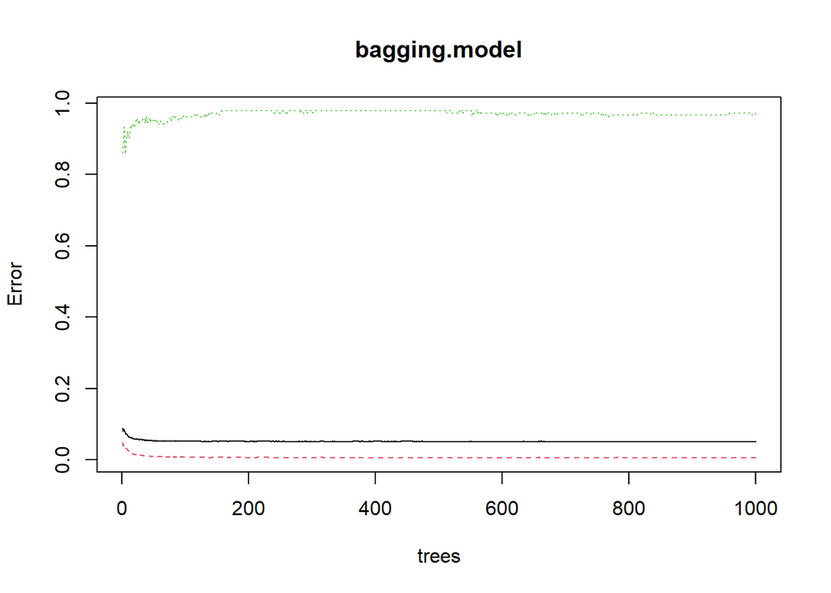

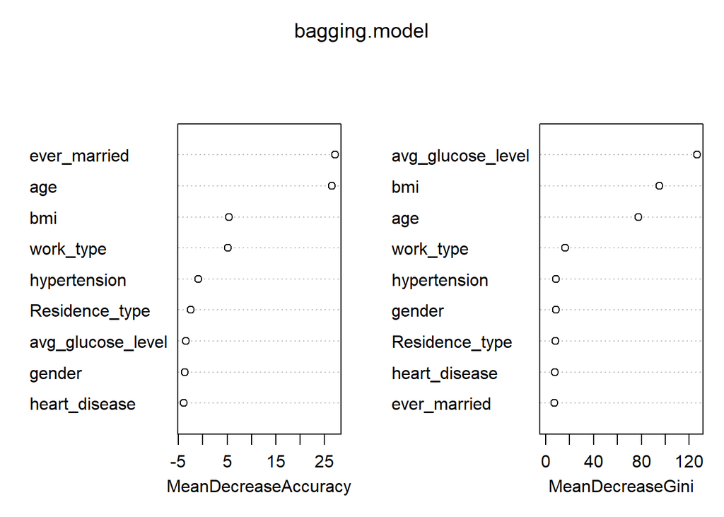

先跑一次不做篩選變數的預測結果:

```
##     predict
## real   0   1
##    0 921   5
##    1  59   1
```

```
## [1] 0.9350913
```

bagging下，不做變數篩選模型的預測準確率為 0.9350913

接著由bagging model所判斷的變數中做篩選，由前面的圖(MeanDecreaseAccuracy, MeanDecreaseGini)整合來看，決定刪掉heart_disease、gender、Residence_type這三個變數，之後以刪除變數後的train做預測。

```
##     predict
## real   0   1
##    0 922   4
##    1  59   1
```

```
## [1] 0.9361055
```

bagging下，做完變數篩選模型的準確率為 0.9361055

# randomforest

在隨機森林中，ntree的值沿用bagging，先將所有變數放入模型，再用`tuneRF()`函數尋找OOB error最小值的mtry，將此最小值設為之後rf的mtry值。

將全部變數放入時，最小的OOB error的mtry=2。

```
## mtry = 3  OOB error = 4.8%
## Searching left ...
## mtry = 2     OOB error = 4.65%
## 0.03125 0.05
## Searching right ...
## mtry = 6     OOB error = 5%
## -0.04166667 0.05
```

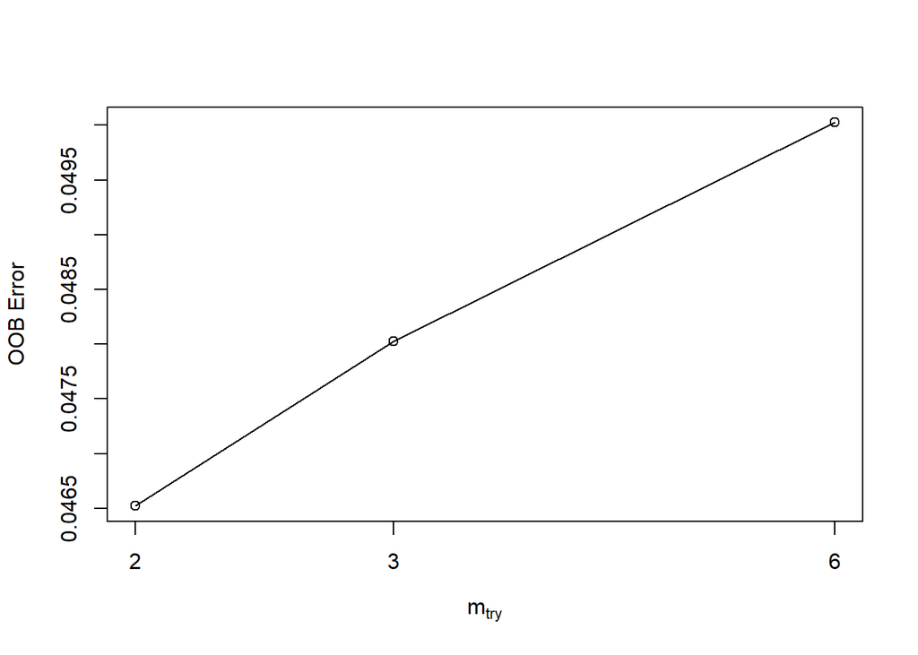

```
##       mtry   OOBError
## 2.OOB    2 0.04652326
## 3.OOB    3 0.04802401
## 6.OOB    6 0.05002501
```

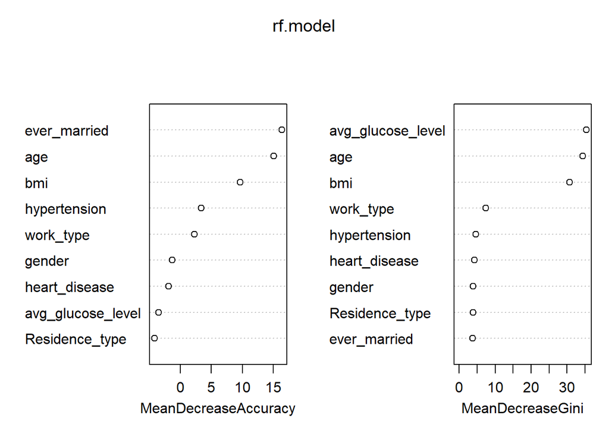

```
##     predict
## real   0   1
##    0 925   1
##    1  60   0
```

```
## [1] 0.9381339
```

randomforest下，不做變數選擇模型預測準確率為0.9381339

之後查看前一步所產生出來的重要變數圖，做變數篩選，最後所選出來的重要變數為:age、ever_married、avg_glucose_level、bmi、hypertension、work_type。

在用`tuneRF()`函數查看合適的mtry值，最後選擇mtry=1。

```
## mtry = 2  OOB error = 4.73%
## Searching left ...
## mtry = 1     OOB error = 4.65%
## 0.01587302 0.05
## Searching right ...
## mtry = 4     OOB error = 4.85%
## -0.02645503 0.05
```

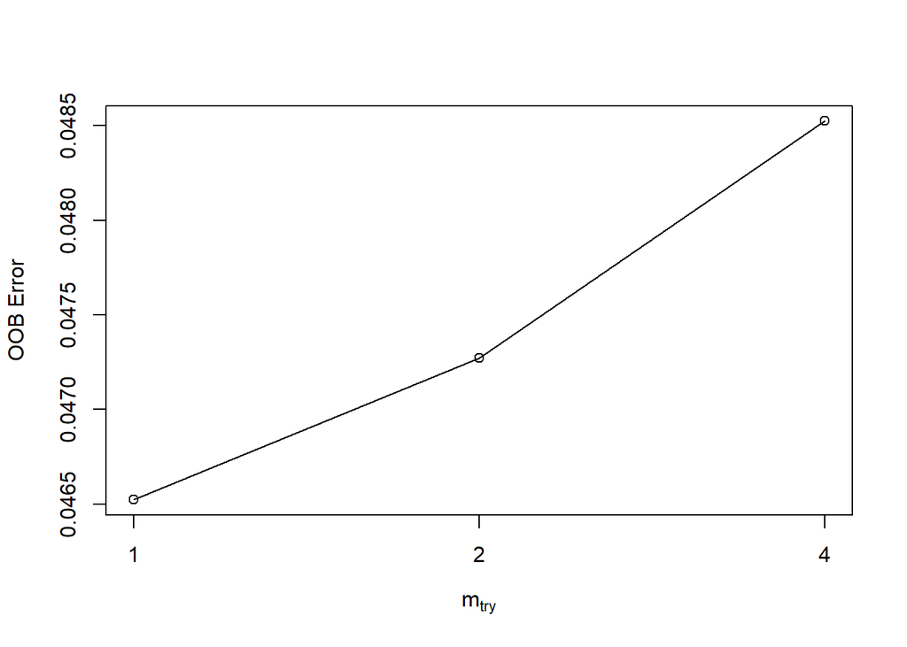

```
##       mtry   OOBError
## 1.OOB    1 0.04652326
## 2.OOB    2 0.04727364
## 4.OOB    4 0.04852426
```

```
##     predict
## real   0   1
##    0 926   0
##    1  60   0
```

```
## [1] 0.9391481
```

以randomforest所選出來的重要變數建模準確率為 0.9391481

# 改變資料

由於全部的資料中預測變數stroke，0的筆數有4738筆(95%)，1的筆數有246筆(5%)，比例上差異懸殊，因此將原資料隨機切成20等分(4738/246)，再對每一筆資料取80%訓練集、20%測試集，用80%的訓練集做模型預測，並將20筆的模型預測準確率取中位數。

*這20筆皆放入只選出重要變數的模型做預測!

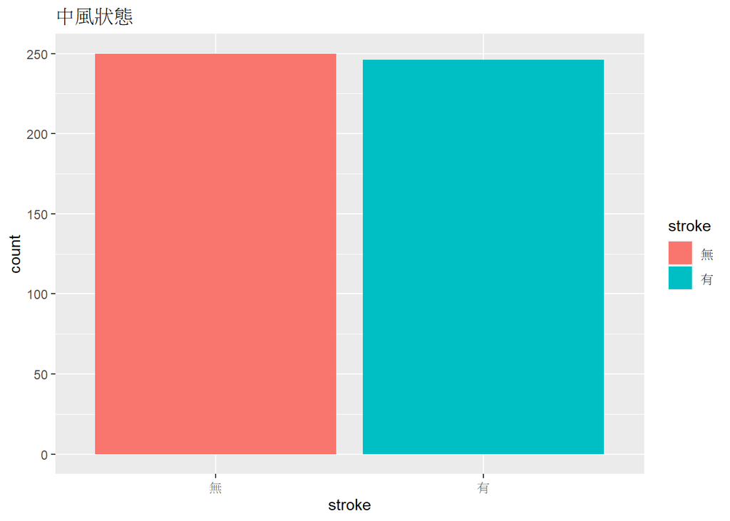

```
## [1] 0.7777778 0.7457162 0.7605416
```

這張長條圖是20筆資料的其中一筆，可以看到stroke的0和1的筆數相差不多。

# 總整理/總結

- loglogistic regression(只放重要變數):0.7777778
- bagging(只放重要變數): 0.7457162
- randomforest(只放重要變數, sampsize=預設值):0.7605416

最後選擇loglogistic regression(只放重要變數)，因為此模型放入的是stroke中0和1的比例差不多，具備測試變異小的性質，也就是說當今天不同資料放入模型中，預測結果都差不多為0.7777778

### 附錄A

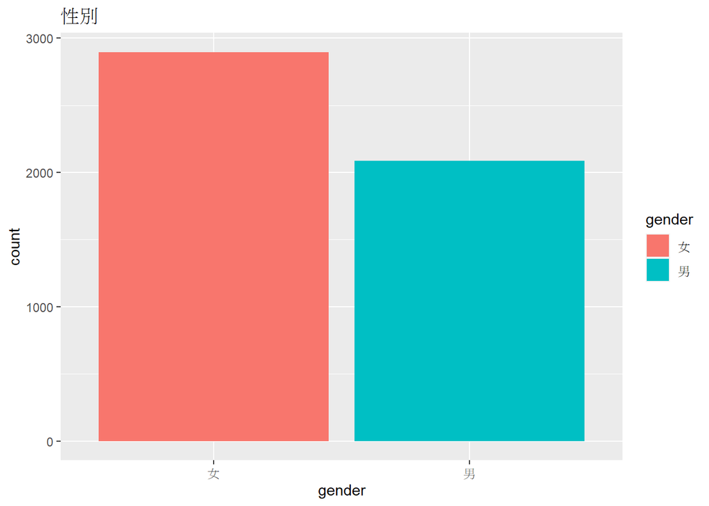

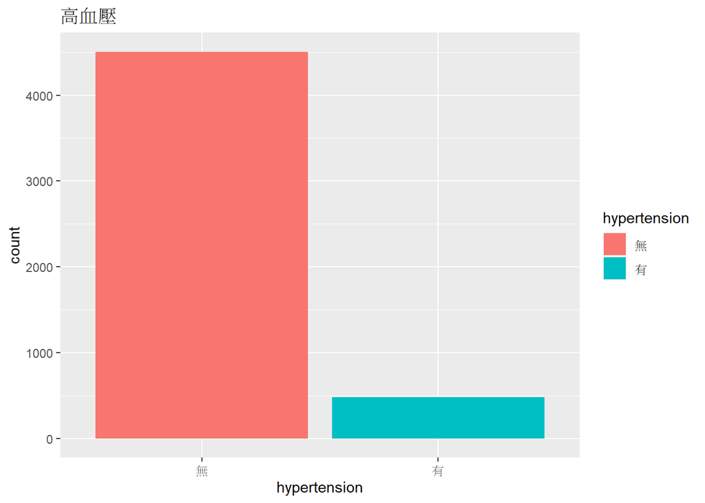

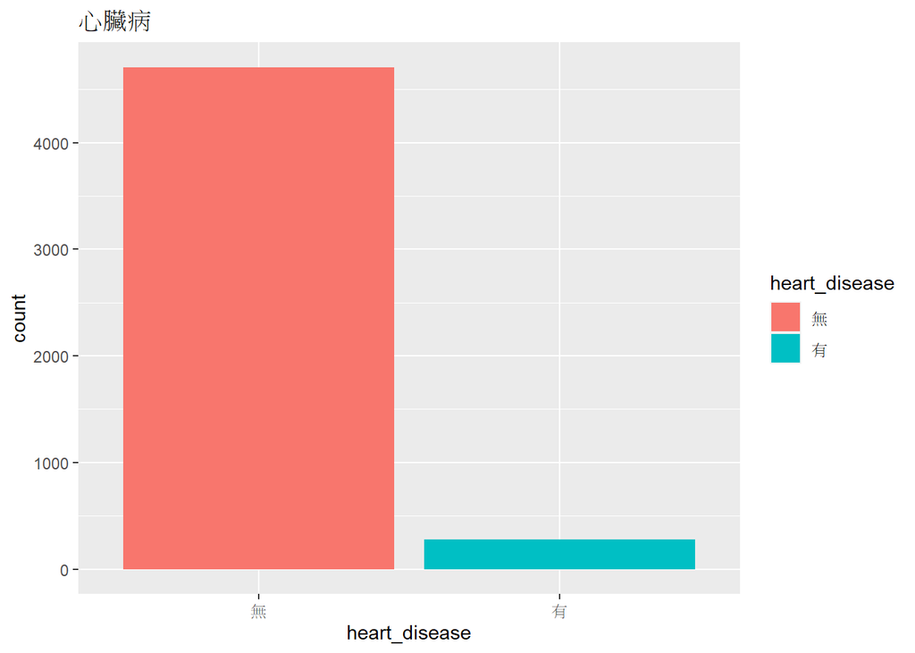

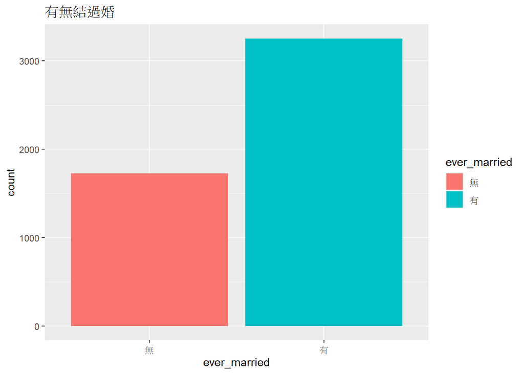

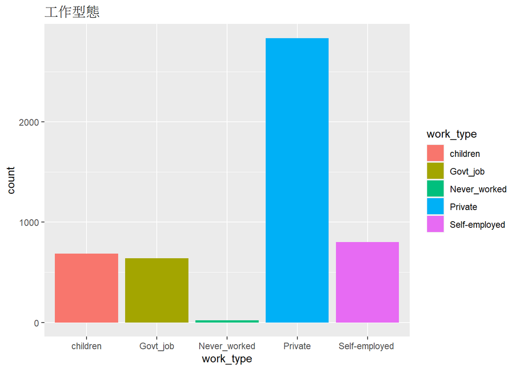

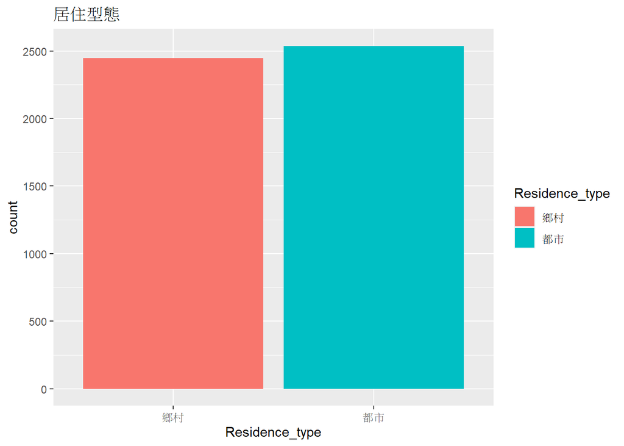

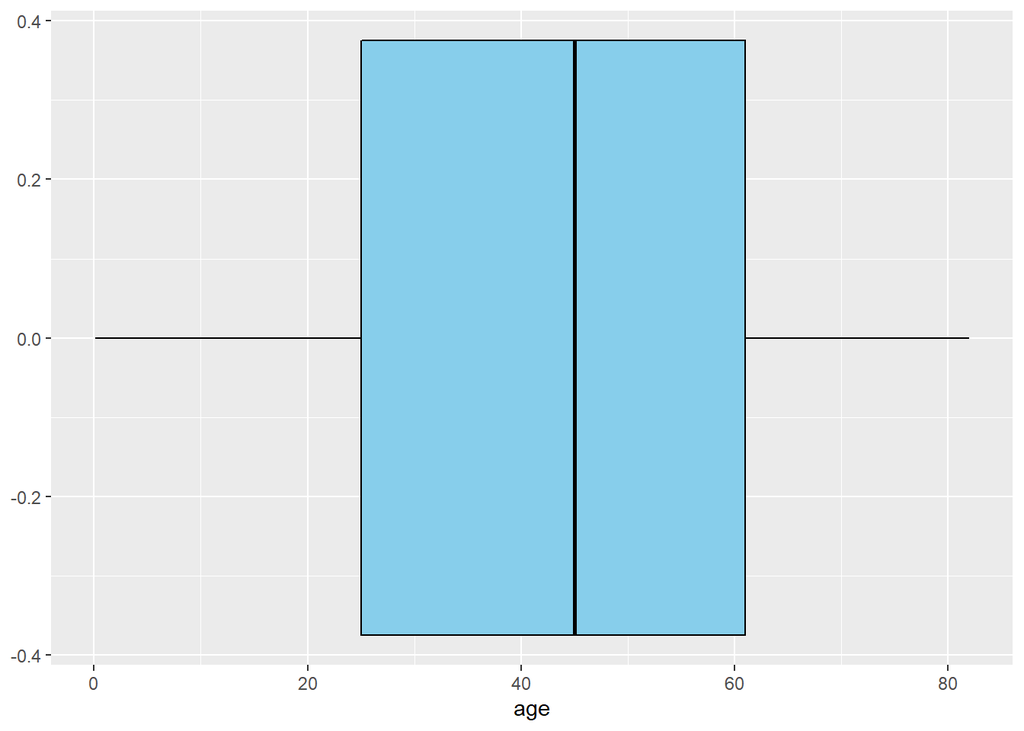